# MSDS 597 HW7

Shiqin Cai

November 3, 2016

First, we downlad the `mortality.csv` file and save it into the folder named `data`.

We then clean the `mortality` as the folllowing steps.

```r
mortality$Year <- mortality$Year %>% str_sub(end = 4) %>% as.integer()
mortality$Mortality.num <- mortality$`Maternal mortality ratio (per 100 000 live births)` %>%
  str_extract("[0-9 ]+\\[") %>% str_replace_all("[ \\[]", "") %>% as.integer()
mortality$Lower_bound <- mortality$`Maternal mortality ratio (per 100 000 live births)` %>%
  str_extract("\\[[ 0-9]+") %>% str_replace_all("[ \\[]", "") %>% as.integer()
mortality$Upper_bound <- mortality$`Maternal mortality ratio (per 100 000 live births)` %>%
  str_extract("-[ 0-9]+") %>% str_replace_all("[ -]", "") %>% as.integer()
mortality <- select(mortality, -`Maternal mortality ratio (per 100 000 live births)`)
head(mortality)
```

```
## # A tibble: 6 × 6
##       Country  Year `Births attended by skilled health personnel (%)`
##         <chr> <int>                                             <dbl>
## 1 Afghanistan  2015                                                NA
## 2 Afghanistan  2013                                              45.2
## 3 Afghanistan  2000                                                NA
## 4 Afghanistan  1990                                                NA
## 5     Albania  2015                                                NA
## 6     Albania  2008                                              99.3
## # ... with 3 more variables: Mortality.num <int>, Lower_bound <int>,
## #   Upper_bound <int>
```

Next, we download the `income.csv` file and save it into the `data` folder.

We then clean the `income` data as shown below.

```r
income$`2013` <- as.integer(str_replace_all(income$`2013`, " ", ""))
income <- income %>% gather(`2013`:`1990`, key="Year", value="Income")
income$Year <- as.integer(income$Year)
head(income)
```

```
## # A tibble: 6 × 3
##               Country  Year Income
##                 <chr> <int>  <int>
## 1         Afghanistan  2013   2000
## 2             Albania  2013  10520
## 3             Algeria  2013  12990
## 4              Angola  2013   6770
## 5 Antigua and Barbuda  2013  20070
## 6             Armenia  2013   8140
```

After cleaning both data sets, we merge them by `Country` and `Year`, and only retain rows that have non-missing per capital income values and either non-missing maternal mortality values or non-missing percentage attended births. This results in the new data frame `df`.

```r
df <- merge(mortality, income, by=c("Country", "Year"))
df_cleaned <- df %>%
  filter(!is.na(Income) & (!is.na(Mortality.num) | !is.na(`Births attended by skilled health personnel (%)`)))
```

Since only year 1990 and 2000 contains non-missing value, the following graph displays the number of maternal mortality against income. And the plots below show that countries with lower gross income have greater number of maternal mortality. Comparing the number of mortality in 2000 with that in 1990, we see that the number of maternal mortality decreased in most countries because their national gross income increased in 2000.

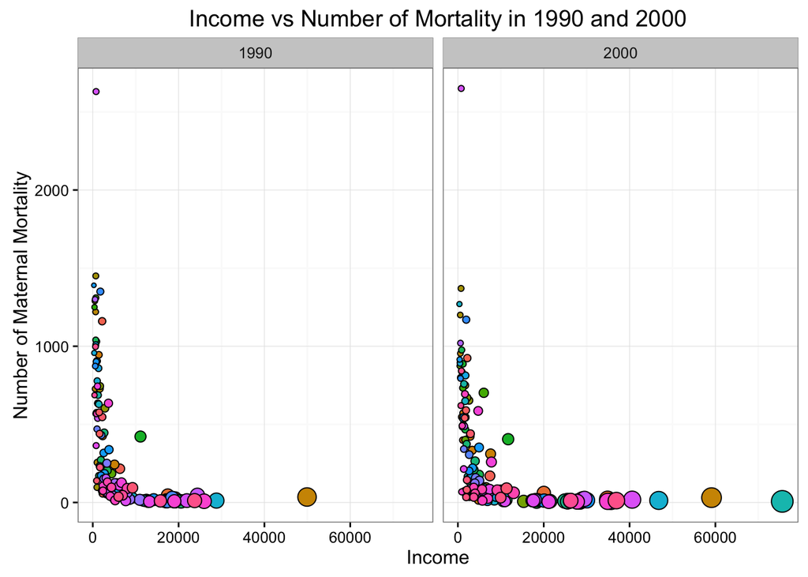

```r
# income, maternal mortality
df_cleaned %>% filter(!is.na(Income) & !is.na(Mortality.num)) %>%
  ggplot(aes(x=Income, y=Mortality.num, fill=Country)) +
  geom_point(aes(size=Income), pch=21, show.legend = F) +
  facet_wrap(~ Year) + theme_bw() +
  ggtitle("Income vs Number of Mortality in 1990 and 2000") +
  ylab("Number of Maternal Mortality")
```

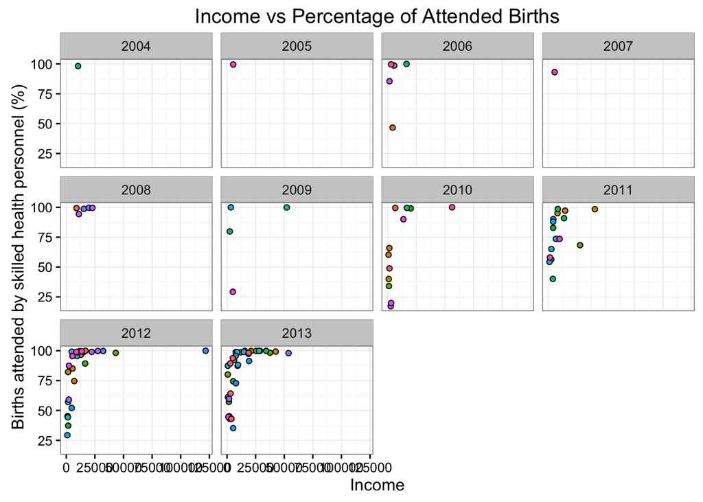

```r
# income, percentage attended births
df_cleaned %>% filter(!is.na(Income) & !is.na(`Births attended by skilled health personnel (%)`)) %>%
  ggplot(aes(x=Income, y=`Births attended by skilled health personnel (%)`, fill=Country)) +
  geom_point(pch=21, show.legend = F) + theme_bw() +
  facet_wrap(~ Year) + ggtitle("Income vs Percentage of Attended Births")
```

```r
head(df_cleaned)
```

```
##       Country Year Births attended by skilled health personnel (%)
## 1 Afghanistan 2013                                            45.2
## 2     Albania 1990                                              NA
## 3     Albania 2000                                              NA
## 4     Albania 2008                                            99.3
## 5     Algeria 1990                                              NA
## 6     Algeria 2000                                              NA
##   Mortality.num Lower_bound Upper_bound Income
## 1            NA          NA          NA   2000
## 2            71          58          88   2840
## 3            43          33          56   4370
## 4            NA          NA          NA   8920
## 5           216         141         327   6330
## 6           170         118         241   7460
```

```r
write_csv(df_cleaned, path = "data/cleaned_df.csv")
```

We only keep the most recent year record for each country using the `max(row_number())`. Since the first letter of the country names in the data frame are capitalized, we need to convert the country names to lower case. We also need to remove the `-` in the country names, and trim them.

```r
df_country_demographics <- df_cleaned %>% group_by(Country) %>% filter(row_number()==max(row_number()))
df_country_demographics$Country <- df_country_demographics$Country %>%
  tolower() %>% str_replace("\\([a-z ]+\\)", "") %>% str_trim() %>%
  str_replace_all("-", " ")
```

The world map of maternal mortality using the most recent year of each country is shown below. From the map, we see that the number of maternal mortality is highest in Africa, while United States has relatively low number of maternal mortality.

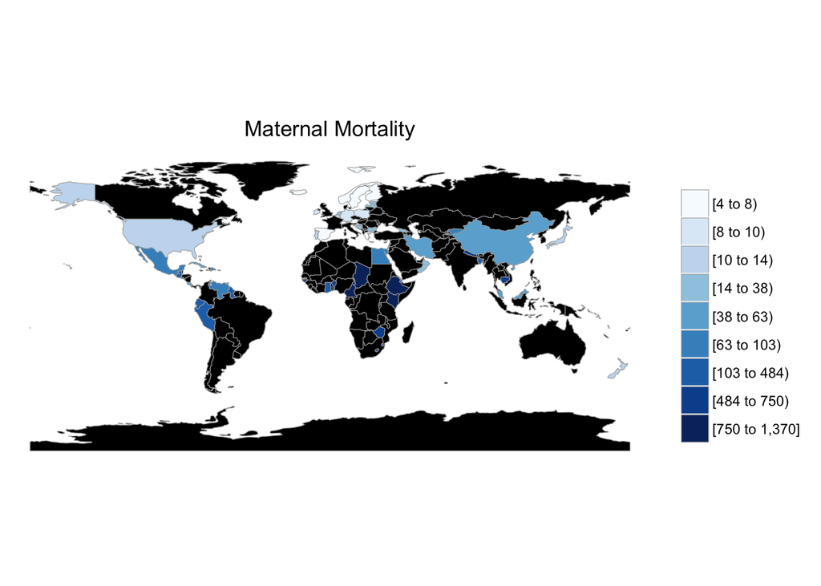

```r
df_country_demographics %>% dplyr::rename(region = Country, value = Mortality.num) %>%
  country_choropleth(title = "Maternal Mortality", num_colors = 9)
```